# API Keys and a Quarto Dashboard

Lecture 09b  
POLS 6394 · Thursday, October 22

## Today

- Recall 09a: request, inspect, reshape
- Store an API key outside the coursework repository
- Read bills from Congress.gov
- Present a count, chart, and table in a Quarto dashboard
- Start Problem Set 5: build your own dashboard

# From 09a to today

## The same steps, another API

In 09a, we built a request, inspected its response, and unpacked nested records.

Congress.gov adds a key. A dashboard gives us another way to present the results.

## Setup

Before class, restart R and **Source** the updated `install_packages.R`; it adds usethis, which opens your `.Renviron` file.

Run this setup chunk as written. jsonlite reads JSON; the saved responses in `Data/congress/` let the document render without a key or a live request.

```r
library(tidyverse)
library(jsonlite)
```

## A huge shortcut: `flatten = TRUE`

In 09a, turning nested records into a table took four steps:

```r
response <- fromJSON(path, simplifyVector = FALSE)
tibble(record = response$bills) |>
  unnest_wider(record) |>
  unnest_wider(latestAction, names_sep = "_")
```

When every record has the same fields, jsonlite can do all of that for you:

```r
fromJSON(path, flatten = TRUE)$bills
```

Congress.gov’s bill records are regular like this, so today we use the shortcut.

## What `flatten = TRUE` does

By default, `fromJSON()` turns a list of same-shaped records into a data frame, but a nested object (here, `action`) stays packed inside one column. `flatten = TRUE` unpacks it into ordinary columns named `parent.child`.

```r
json <- '[
  {"bill": "HR 1", "action": {"date": "2025-01-03", "text": "Introduced"}},
  {"bill": "HR 2", "action": {"date": "2025-02-10", "text": "Passed House"}}
]'
names(fromJSON(json))
```

```
[1] "bill"   "action"
```

```r
fromJSON(json, flatten = TRUE)
```

```
  bill action.date  action.text
1 HR 1  2025-01-03   Introduced
2 HR 2  2025-02-10 Passed House
```

`json` is a tiny JSON example typed as an R string: single quotes outside, so the double quotes inside are kept. Without `flatten`, there are two columns; with it, `action` becomes `action.date` and `action.text`.

# API keys

## Why a key?

An API key identifies who’s asking and lets a service count their requests.

Treat it like a password. Keep it out of scripts, workbooks, Git commits, and rendered output.

Congress.gov offers a free key at [its signup page](https://api.congress.gov/sign-up/).

## What a key buys you

Congress.gov uses api.data.gov keys to identify the person making a request and count their usage.

Congress.gov currently permits **5,000 requests per hour**. Other api.data.gov services may set different limits.

A request counts even if it returns only a few records. Save responses you want to reuse rather than fetching them on every render.

## Environment variables

An environment variable is a **named setting** that a program can read. We can keep its value separate from the script.

`Sys.getenv("CONGRESS_API_KEY")` asks R for the value stored under that name. Sharing the code doesn’t share the value.

`HOME` points to a home folder; `PATH` lists folders where the system looks for programs.

Safe Console example:

```r
Sys.getenv("HOME")
```

## Environment files

An environment file is plain text with one `NAME=value` setting per line. It isn’t encrypted.

R reads `.Renviron` at startup, which is why we restart R after editing it.

The user-level `~/.Renviron` is in your home folder and can supply settings across projects. We’ll use user scope rather than a project copy.

Python and JavaScript tools often load similar `.env` files. Keep these files out of Git too.

A leading dot usually hides files on macOS/Linux; Windows may show them. The helper below opens the file directly.

## Open your home .Renviron file

Run this in the Console, not during rendering:

```r
usethis::edit_r_environ()
```

`usethis::` calls a function from the usethis package without loading the whole package. This opens `~/.Renviron`, a plain-text file in your home folder, creating it if needed. The default `scope = "user"` keeps it outside this project.

The restart reminder is expected. Keep any existing entries. In the **`.Renviron` tab**, add a line in this form:

```
CONGRESS_API_KEY=paste-key-here
```

## Save the entry

**Type this in `.Renviron`, never in your workbook or dashboard.**

- In the `.Renviron` tab, replace the placeholder with your emailed key.
- Don’t add quotes or spaces around `=`.
- Finish the line with Enter, then save.

The coursework `.gitignore` also excludes `.Renviron`. Keep keys outside the project anyway.

## Restart and check

Choose **Session → Restart R**, then rerun Setup. R reads `.Renviron` at startup. Check for the key in the Console without printing it:

```r
nzchar(Sys.getenv("CONGRESS_API_KEY"))
```

`Sys.getenv()` reads the variable. `nzchar()` asks whether it contains any characters.

`TRUE` means R found a value, not that Congress.gov accepted it. If `FALSE`, check the entry’s name, save, and restart R again.

## Your Turn: store and check your key

*~4 minutes.*

Store your Congress.gov key, restart R, rerun Setup, and run the check above. Record only `TRUE` or “key pending” in the workbook, never the key.

If your key hasn’t arrived, continue with the saved response. You can finish the local parts without it.

# Congress.gov

## The address

```
https://api.congress.gov/v3/bill/119?format=json&api_key=CONGRESS_API_KEY
```

`bill/119` selects bills and resolutions from the 119th Congress (2025–2026). `format=json` requests JSON rather than XML. The API key is another parameter, but we’ll read its value from R’s environment rather than type it into this document.

Here, `CONGRESS_API_KEY` stands for its stored value, not those literal letters.

## A function that adds the key

Define the function as written. Defining it sends nothing; calling it makes the request.

```r
congress_get <- function(path, query = "") {
  key <- Sys.getenv("CONGRESS_API_KEY")
  url <- paste0(
    "https://api.congress.gov/v3/", path,
    "?format=json", query, "&api_key=", key
  )
  result <- fromJSON(url, flatten = TRUE)
  return(result)
}
```

## What the function builds

For `path = "bill/119"` and the default `query = ""`, `paste0()` joins the pieces without spaces:

```
https://api.congress.gov/v3/bill/119?format=json&api_key=CONGRESS_API_KEY
```

- `Sys.getenv()` reads the saved key into the local `key` object.
- `path` chooses the endpoint; `query` allows extra parameters, or nothing.
- `url <- paste0(...)` joins the address, path, parameters, and key.
- jsonlite’s `fromJSON()` requests and parses the response; `flatten = TRUE` returns the records as a flat table, as on the shortcut slides.
- `return(result)` sends that parsed response back.

In this illustration, `CONGRESS_API_KEY` stands for the **value** read from the environment variable of that name. The real key isn’t printed here; the function uses it when making the request.

## Keep live calls out of renders

The code doesn’t print the key, but a failed live call may include it in an error message. Remove the key before sharing an error. Keep live calls disabled during rendering.

## When the key is wrong or missing

An optional keyless call in the Console shows a rejected request:

```r
fromJSON("https://api.congress.gov/v3/bill/119?format=json")
```

The service returns:

| Request | HTTP status | Error code |
| --- | --- | --- |
| No key | 403 (forbidden) | `API_KEY_MISSING` |
| Invalid key | 403 (forbidden) | `API_KEY_INVALID` |

`fromJSON()` may report only the HTTP error. Check your local key entry and restart R.

## Read the first response

With a key, run the next call in the Console. Don’t remove its `eval: false` line.

```r
bills <- congress_get(path = "bill/119")
```

For rendering and the worked examples, use the response saved on October 16:

```r
bills <- fromJSON("Data/congress/bills_119.json", flatten = TRUE)
names(bills)
```

```
[1] "bills"      "pagination" "request"
```

## Inspect the envelope

`bills` holds the records; `pagination` holds the search information. The API returns 20 records by default, not every matching bill. `bills$bills` is a data frame with one row per record, so `nrow()` counts them.

```r
bills$pagination$count
```

```
[1] 19696
```

```r
nrow(bills$bills)
```

```
[1] 20
```

## Your Turn: matches and returned records

*~2 minutes.*

Use the saved `bills` response and the two checks on the preceding slide.

How many records matched the search? How many came back on this page?

Explain the difference in one sentence in the workbook.

## Look at the records

`glimpse()` lists the columns. `flatten = TRUE` turned the nested `latestAction` object into columns joined with a dot, such as `latestAction.actionDate` and `latestAction.text`:

```r
glimpse(bills$bills)
```

```
Rows: 20
Columns: 13
$ congress                <int> 119, 119, 119, 119, 119, 119, 119, 119, 119, 1…
$ introducedDate          <chr> "2025-01-03", "2025-01-03", "2025-01-03", "202…
$ number                  <chr> "134", "173", "209", "68", "166", "170", "105"…
$ originChamber           <chr> "House", "House", "House", "House", "House", "…
$ originChamberCode       <chr> "H", "H", "H", "H", "H", "H", "H", "H", "H", "…
$ title                   <chr> "Protecting our Communities from Sexual Predat…
$ type                    <chr> "HR", "HR", "HR", "HR", "HR", "HR", "HR", "HR"…
$ updateDate              <chr> "2026-09-19", "2026-03-21", "2025-11-20", "202…
$ updateDateIncludingText <chr> "2026-09-19", "2026-03-21", "2025-11-20", "202…
$ url                     <chr> "https://api.congress.gov/v3/bill/119/hr/134?f…
$ latestAction.actionDate <chr> "2025-01-03", "2025-01-03", "2025-01-03", "202…
$ latestAction.text       <chr> "Referred to the House Committee on the Judici…
$ latestAction.actionTime <chr> NA, NA, NA, NA, NA, NA, NA, NA, NA, NA, NA, NA…
```

## Check that `flatten = TRUE` worked

`flatten = TRUE` rarely fails with an error. When records aren’t regular, it quietly leaves something unflattened. So check two things:

- **Rows:** `nrow()` should equal the number of records returned.
- **List columns:** in `glimpse()`, a column marked `<list>` wasn’t flattened.

Our bills pass both checks: 20 rows and no `<list>` columns. The Federal Register rules from 09a don’t. Their `agencies` column stays `<list>` because each rule lists a different number of agencies. When a check fails, switch to the 09a route: `simplifyVector = FALSE`, then `unnest_wider()` or `unnest_longer()`.

## Bills into a tibble

`as_tibble()` turns the data frame into a tibble, so it prints compactly like the other tables in this course.

```r
bill_table <- as_tibble(bills$bills)
```

Each row is one bill or resolution in the saved response.

## Five sampled rows

Here are five sampled rows:

```r
set.seed(6394)
bill_table |>
  slice_sample(n = 5) |>
  select(type, number, latestAction.actionDate, title)
```

```
# A tibble: 5 × 4
  type  number latestAction.actionDate title
  <chr> <chr>  <chr>                   <chr>
1 HR    170    2025-01-03              USPS Subpoena Authority Act
2 HR    144    2025-01-16              Tennessee Valley Authority Salary Transp…
3 HR    209    2025-01-03              Inaction Has Consequences Act
4 HR    134    2025-01-03              Protecting our Communities from Sexual P…
5 HR    37     2025-01-03              Proposing a Federal debt limit amendment…
```

## Which kinds came back?

`HR` is a House bill, `HRES` a House resolution, and `HJRES` a House joint resolution. Count the types within this page:

```r
bill_table |>
  count(type)
```

```
# A tibble: 3 × 2
  type      n
  <chr> <int>
1 HJRES     3
2 HR       16
3 HRES      1
```

These are counts among the 20 saved records, not the whole Congress. Don’t describe this page as a representative sample or assume its records are sorted by action date.

# A small Quarto dashboard

## Why a dashboard?

A paper makes one argument, in order, over 30 pages. A dashboard is the TL;DR: a few results on one page for a reader who will give you 30 seconds. (That is most readers.)

- **Readers who won’t read the paper:** an adviser between meetings, policy staff, a client. Agencies, think tanks, and newsrooms publish dashboards for this reason.
- **Numbers computed, not typed:** 19,696 comes from the API response. Re-render with a fresh response, and every card updates.
- **A check on your own work:** a dashboard of data you’re collecting shows problems at a glance.
- **Nothing new to install:** a Quarto document with R chunks, rendered to one HTML file you can share.

It’s also a default final-project output, and Problem Set 5 builds on this one.

## From a tibble to a page

A dashboard brings a few results together on one page: a headline number, a chart, and a table. This one is an HTML file built by Quarto; it doesn’t need an R server.

Open `09b-dashboard.qmd` in a second editor tab and render it. Keep the workbook open too.

Its own setup reads and reshapes the saved bills. It doesn’t depend on objects in your Console.

## The rendered dashboard

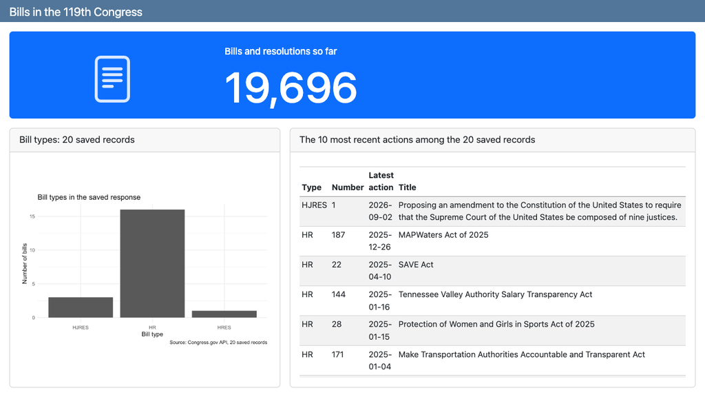

Rendered Congress.gov dashboard: a total count above a chart of the 20 saved records and a table of the 10 most recent.

## The format line

**Example only: don’t paste this into `09b-dashboard.qmd`.** Its existing YAML is shown below.

The YAML selects a dashboard rather than a regular HTML document:

```yaml
format:
  dashboard:
    embed-resources: true
```

`embed-resources: true` bundles the supporting files into the HTML. You can open that rendered file in a browser; no API key is included.

## Where the rendered page goes

Rendering `09b-dashboard.qmd` creates **09b-dashboard.html** beside it.

Open that HTML in your browser. Its `embed-resources: true` setting keeps the supporting files inside it.

Your coursework `.gitignore` excludes `*.html`. Commit the **QMD**, not the rendered HTML.

Anyone receiving that HTML can read its displayed data. Never put a key in it.

## The whole file at a glance

**Example only: don’t paste this into `09b-dashboard.qmd`.** This is an outline of the existing file.

````markdown
---
title: "Bills in the 119th Congress"
format: dashboard
---
```{r}
#| include: false
# Read data; create type_plot and recent_table
```
## Row {height=25%}
```{r}
#| content: valuebox
# ...value-box code...
```
## Row {height=75%}
### Column {width=40%}
```{r}
type_plot
```
### Column {width=60%}
```{r}
knitr::kable(recent_table)
```
````

- **YAML:** the page title and dashboard format.
- **Hidden setup:** data and objects; no card.
- **First row:** the headline count.
- **Second row:** chart on the left, table on the right.

This is an outline. Follow along in the actual file.

## Rows divide the page

**Example only: don’t paste this into `09b-dashboard.qmd`.** These row headings are already in the file.

```markdown
## Row {height=25%}

## Row {height=75%}
```

`## Row` starts a horizontal row. Its `height` sets its share of the page.

The top row has one value box; you’ll build two in Problem Set 5.

The bottom row holds the chart and table. These heights add up to 100%.

## Columns divide a row

**Example only: don’t paste this into `09b-dashboard.qmd`.** These column headings are already in the file.

Under the second `## Row`:

```markdown
### Column {width=40%}

### Column {width=60%}
```

`### Column` starts a column within that row.

The chunk after the first heading fills the left 40%. The chunk after the second fills the right 60%.

## Each chunk becomes a card

**Example only: don’t paste this into `09b-dashboard.qmd`.** This chart chunk is already in the file.

A chunk’s output fills a card. Its `title` names the card; `include: false` hides the setup chunk while still running it.

```r
#| title: "Bill types: 20 saved records"
type_plot
```

The chart uses familiar ggplot code. The table uses knitr’s `kable()`, as in 06b. You can change the calculations without changing the page layout.

## A value box

**Example only: don’t paste this into `09b-dashboard.qmd`.** The first value-box chunk is already in the file.

This is the value-box chunk from the example:

```r
#| content: valuebox
#| title: "Bills and resolutions so far"
list(
  icon = "file-text",
  color = "primary",
  value = comma(bills$pagination$count)
)
```

`content: valuebox` presents the output as a large number.

`comma()` comes from scales, which the dashboard loads in its setup. It displays 19,696 with a thousands separator. In 06a, `label_comma()` made labels for an axis; `comma()` formats a single number.

## Icons and theme colors

`icon` takes a [Bootstrap icon name](https://icons.getbootstrap.com/), such as `"file-text"` or `"bank"`.

`color` takes a theme color name. Six common choices:

| Name | Default appearance |
| --- | --- |
| `primary` | Blue |
| `secondary` | Gray |
| `success` | Green |
| `info` | Bright blue |
| `warning` | Yellow/orange |
| `danger` | Red |

Colors change with the theme. You don’t need another R package for these icons.

## Any computed value can be a value box

**Example only: don’t paste this into `09b-dashboard.qmd`.**

For example, count the different bill types in the saved page:

```r
#| content: valuebox
#| title: "Bill types in the 20 saved records"
list(
  icon = "collection",
  color = "info",
  value = n_distinct(bill_table$type)
)
```

The saved page contains **3 bill types**. The value can be a calculation from the records, not just a number from the envelope.

## Change the chart in setup, not in the layout

In the dashboard’s setup, `type_plot` contains the ggplot code.

Change its `labs(title = ...)` to change the title **inside the plot**, then render again.

The later chunk just prints `type_plot`. Its `#| title:` controls the **card heading** above the plot.

You can revise the chart without rearranging the rows and columns.

## Themes

**Add this to `09b-dashboard.qmd`:** update the existing YAML at the top to match the block below; don’t add a second `format:` block.

```yaml
format:
  dashboard:
    embed-resources: true
    theme: flatly
```

`cosmo`, `flatly`, and `lux` are [Bootswatch themes](https://bootswatch.com/). Try one name to restyle the page, including its value-box colors.

The ggplot image keeps the `theme_minimal()` set in setup; the page theme doesn’t change it.

## Your Turn: a card title and a theme

*~2 minutes.*

In `09b-dashboard.qmd`:

1. Rename one `#| title:` so it says exactly what that card shows.
2. Add `theme: flatly`, `theme: cosmo`, or `theme: lux` under `dashboard:`.
3. Render. Name one thing the theme changed on the page (for example, the title bar, fonts, or value-box color). Did the bar chart change?

Record the title and theme you kept in the workbook.

## Text in a card

**Example only: don’t paste this into `09b-dashboard.qmd`.**

A short note can explain what the displayed data cover:

```markdown
::: {.card title="About these records"}
The chart covers 20 saved records; the table shows
the 10 with the most recent actions.
:::
```

`::: {.card ...}` starts the card; `title` names it. The closing `:::` ends it.

This illustrates a text card; it isn’t required. No R chunk is needed.

## Pages, rows, columns

**Example only: don’t paste this into `09b-dashboard.qmd`.**

A single `#` heading adds a dashboard page. Within it, rows and columns work as before:

````markdown
# Overview
## Row
### Column
# Details
## Row
### Column {.tabset}
```{r}
#| title: "Chart"
type_plot
```
```{r}
#| title: "Records"
knitr::kable(recent_table)
```
````

- `#`: a page, linked from the navigation bar.
- `##`: a row within that page.
- `###`: a column within that row.
- `{.tabset}`: show the column’s cards as tabs, one visible at a time.

Pages are an option to recognize; our starter uses one page without a `#` heading. You’ll add pages in Problem Set 5; tabsets are optional.

## Adding a row

**Example only: don’t paste this into `09b-dashboard.qmd`.** Task 2 adds the real row. Adding this example too would give you four rows.

At the end of the file, a new row followed by one chunk makes a full-width card:

````markdown
## Row {height=30%}
```{r}
#| title: "Another view of the saved records"
knitr::kable(recent_table)
```
````

Rebalance **all** row heights when you add a row. For example, 20% + 50% + 30% = 100%.

Problem Set 5 uses rows like this on its own pages.

## Full count versus the page received

The value box uses `pagination$count`: all 19,696 matching records in the saved response’s search. The chart uses only the 20 returned records, and the table shows the 10 of those with the most recent actions. Their titles say so. A large headline count doesn’t turn one page into an analysis of all bills.

## When the render fails

Read the **first error** and its chunk name.

- A missing comma in `list()` prevents R from reading the code.
- An object used before setup creates it gives an “object not found” error.
- A chunk under the wrong heading may render successfully, but appear in the wrong row or column.

For the last problem, check the heading above the chunk.

## A dashboard checklist

- Give every card a title that says what it covers.
- Include the data source in the chart’s caption or a note.
- Format numbers so they’re easy to read.
- Distinguish all matching records from one returned page.
- Keep keys and other private information out of the output.

Check the rendered page, not just the source file.

# Problem Set 5

## Problem Set 5: build your own dashboard

Starts now; due **10:00 AM Tuesday, November 3**. **No AI.**

In `Psets/pset-05/`, you’ll build a two-page dashboard from a nearly blank `pset-05-dashboard.qmd`. Use `09b-dashboard.qmd` as your reference, but don’t edit it for the set.

1. **Read the data (in class):** both saved responses; the Senate table code is supplied.
2. **Overview page (in class):** two value boxes.
3. **A chart and a table:** written by you, following the class example.
4. **Senate page:** a computed value box and the Senate table.
5. **A sidebar (new):** explained in the set.
6. **Check your dashboard** against the checklist.

## Where everything ends up

**Example only: don’t paste this.**

```
YAML: your title (and a theme, if you like)
setup chunk: bills, senate, bill_table, type_plot,
  recent_table, senate_table

# {.sidebar}: notes about the data (Task 5)

# Overview (Tasks 2-3)
  Row (25%): two value boxes
  Row (75%): chart (40%) | bill table (60%)

# Senate (Task 4)
  Row (25%): latest-action value box
  Row (75%): Senate table
```

## In class: Tasks 1–2

*~16 minutes. Amanda and I can help.*

**Task 1:** set your own title; in setup, read both files with `fromJSON(..., flatten = TRUE)`, make `bill_table`, and paste the supplied `senate_table` code. Render: an empty page with your title means the data loaded.

**Task 2:** lay out the Overview page: `# Overview`; a 25% row with two value boxes (all bills and Senate bills, each with `comma()`); a 75% row with two columns holding placeholder text for Task 3.

Use the class example for the form of each piece. Stuck? `pset-05-hints.qmd` has task-by-task hints.

## Before you push: no key in the files

In your coursework project’s Terminal:

```bash
git status
```

Confirm that `.Renviron` isn’t listed. Inspect your workbook and dashboard changes for accidentally pasted keys too.

If you pasted a key into an uncommitted file, remove it before committing. If you already committed it, revoke that key, request a new one, and contact us. Deleting it from the current file doesn’t remove it from history.

## Before Next Class

- Render, inspect, commit, and push **both QMD files**. Keep live calls disabled and keys out of Git.
- **Problem Set 5:** finish the dashboard by hand, no AI. Due **10:00 AM Tuesday, November 3**.
- **Pset 04:** optional midterm practice, ungraded, nothing to submit.
- **October 27:** AI-off midterm (~40 minutes), then our first supervised AI session. AI remains off before and during the midterm.
- **October 29:** no class.

# If Time Remains

## Extension 1a: one page at a time

*~12 minutes for Extension 1.*

Some APIs divide results across pages. In 09a’s Federal Register search, 24 matching rules were spread across three pages. Its `page` parameter selects a page; here we’ll read the three saved pages instead of sending repeated requests.

```r
first <- fromJSON("Data/fedreg/rules_page_1.json", simplifyVector = FALSE)
first$count
```

```
[1] 24
```

```r
first$total_pages
```

```
[1] 3
```

## Extension 1b: a reader for one page

The function reads one saved envelope and returns that page’s records as a tibble. Federal Register records have agency lists of different lengths, so `flatten = TRUE` would leave a `<list>` column; this uses the 09a route. Only the page number changes in the path.

```r
read_rules_page <- function(page) {
  path <- paste0("Data/fedreg/rules_page_", page, ".json")
  response <- fromJSON(path, simplifyVector = FALSE)
  result <- tibble(record = response$results) |>
    unnest_wider(record)
  return(result)
}
```

## Extension 1c: combine and check

`1:first$total_pages` supplies page numbers 1, 2, and 3. `map()` reads each page, then `list_rbind()` stacks the tibbles (08a).

```r
rules_all <- map(1:first$total_pages, read_rules_page) |>
  list_rbind()

nrow(rules_all)
```

```
[1] 24
```

```r
nrow(rules_all) == first$count
```

```
[1] TRUE
```

`TRUE` checks the row count, not duplicates.

## Extension 1: check the identifiers

Reading one page twice and missing another could give the same row count. `n_distinct()` counts different document numbers:

```r
n_distinct(rules_all$document_number) == first$count
```

```
[1] TRUE
```

What does this second `TRUE` tell you that the first one didn’t? Answer in the workbook.

Before collecting pages live, check the API’s usage limits and leave pauses between requests.

## Extension 2: light and dark themes

**Add this to `09b-dashboard.qmd`:** in the existing YAML at the top, replace the single `theme:` setting with the light/dark pair below. Keep just one `format:` block.

*~5 minutes.*

A pair of themes adds a light/dark switch to the title bar:

```yaml
format:
  dashboard:
    embed-resources: true
    theme:
      light: flatly
      dark: darkly
```

Render the dashboard.

## Extension 2: find the toggle

A **toggle** is a switch that flips between two settings: here, light and dark.

Find the **small switch icon at the right end of the title bar**, across from the dashboard title.

Click it to switch modes. Check that card titles and tables are readable in both.

The ggplot remains an image with its own theme. Decide whether that contrast works for your page.